# Impact of the COVID-19 Pandemic on Hypertension Prescriptions Across Scotland

Evie Andrewes

2024-11-25

## 1 Introduction

From the 2011 to the 2022 census, there was an additional **80,700** people in Scotland who reported bad or very bad health. This is thought to be due to an *aging population* (Wroth-Smith 2024). One of the most common age-related diseases is hypertension, or high blood pressure, (Inform 2024). This report will aim to deduce if during the COVID-19 pandemic there was a *significant increase* in prescriptions for hypertension across Scotland.

## 2 Data Exploration and Key Results

To begin, let’s look at the number of prescriptions of common hypertension medications like doxazosin, amlodipine, bisoprolol and atenolol (Inform 2024) (Allen 2024), in a month for each health board in Scotland pre-pandemic (August 2019) and post-pandemic (August 2022).

```r
library(tidyverse)
library(janitor)
library(gt)
library(here)
library(sf)
#Libraries for project

`load_clean_data` <- function(url) {
  read_csv(url) %>%
    clean_names()}
#Creates a function so loading and cleaning data from a url can be streamlined.

data_and_hbs <- c(
  "data_august2019" = "https://www.opendata.nhs.scot/dataset/84393984-14e9-4b0d-a797-b288db64d088/resource/5c667230-4201-4a09-949d-3e6cc3a4ec19/download/pitc201908.csv",
  "data_august2022" = "https://www.opendata.nhs.scot/dataset/84393984-14e9-4b0d-a797-b288db64d088/resource/49fa5784-be06-4015-bc6d-9b5db8726473/download/pitc202208.csv",
  "HB_fullnames" = "https://www.opendata.nhs.scot/dataset/9f942fdb-e59e-44f5-b534-d6e17229cc7b/resource/652ff726-e676-4a20-abda-435b98dd7bdc/download/hb14_hb19.csv")
#Links for Prescriptions from August 2019 and August 2022, as well as data for the names of Health Boards across Scotland.

clean_datasets_with_hbs <- data_and_hbs %>%
  map(~ load_clean_data(.x))
#Here the map function is loading and cleaning all of the data.

joined_datasets <- c("data_august2019", "data_august2022") %>%
  map(~ clean_datasets_with_hbs[[.x]] %>%
    full_join(clean_datasets_with_hbs$HB_fullnames,by = if (.x == "data_august2019") c("hbt2014" = "hb") else c("hbt" = "hb")) %>%
      select(hb_name, bnf_item_description, paid_quantity))
#Map is used to pull datasets that we want from the cleaned data. Then joined by HB name (depending on what this variable is called). We use [[]] for .x because it's a changing or dynamic variable.

hypertension_drugs <- c(
  "DOXAZOSIN" = "Doxazosin Prescriptions",
  "BISOPROLOL" = "Bisoprolol Prescriptions",
  "AMLODIPINE" = "Amlodipine Prescriptions",
  "ATENOLOL" = "Atenolol Prescriptions")
#Here a named vector is created for our hypertension drugs.

combined_hypertension_summary <- joined_datasets %>%
  map2_df(c(2019, 2022), ~ .x %>%
    mutate(drug_type = str_extract(bnf_item_description, paste(names(hypertension_drugs), collapse = "|")),
           drug_type = hypertension_drugs[drug_type]) %>%
    filter(!is.na(drug_type)) %>%
    group_by(hb_name, drug_type) %>%
    summarize(total_paid_quantity = sum(paid_quantity)) %>%
      mutate(year = .y))
#Now the named vector can be used to pull out the drugs of interest using names and str_extract. This returns the value we want instead of TRUE/FALSE like str_detect.The year column is created using the second input of the map2_df function (y).
```

The prescription and health board data has been filtered to show the number of each hypertension medication for each health board in August 2019 and August 2022. Now let’s plot a lollipop chart that shows *the difference between the number of prescriptions* in August 2019 and August 2022 to see how they’ve changed.

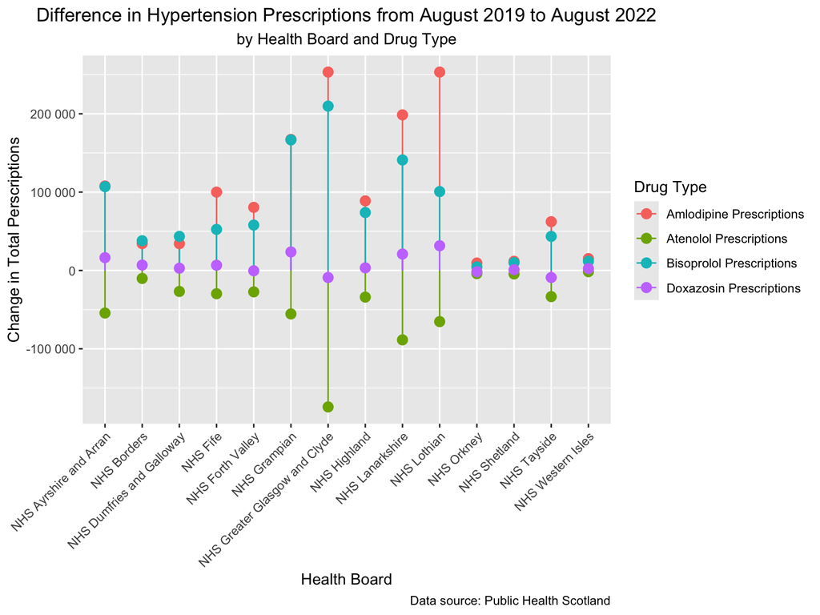

```r
combined_hypertension_summary_diff <- combined_hypertension_summary %>%
  group_by(hb_name, drug_type) %>%
  pivot_wider(names_from = year, values_from = total_paid_quantity) %>%
  mutate(diff = `2022` - `2019`) %>%
  filter(!is.na(diff))
#Calculates difference between drug prescriptions by year.

hypertension_plot <- ggplot(combined_hypertension_summary_diff, aes(x = diff, y = hb_name, color = drug_type)) +
  geom_segment(aes(xend = 0, yend = hb_name), linewidth = 0.5) +
  geom_point(size = 3) +
  coord_flip() +
  labs(title = "Difference in Hypertension Prescriptions from August 2019 to August 2022", subtitle = "by Health Board and Drug Type", x = "Change in Total Perscriptions", y = "Health Board", color = "Drug Type", caption = "Data source: Public Health Scotland") +
  scale_x_continuous(labels = scales::label_number()) +
  theme(plot.title = element_text(hjust = 0.5), plot.subtitle = element_text(hjust = 0.5), axis.text.x = element_text(angle = 45, hjust = 1))
#Here the scales_x_continuous() function changes our y axis (as we have used coord_flip()) to non-scientific notation.
#geom_segment() was used to create the lollipop sticks on the graph.

hypertension_plot
```

### 2.1 Chart Results

```r
hypertension_table <- combined_hypertension_summary_diff %>%
  filter(hb_name %in% c("NHS Lothian", "NHS Greater Glasgow and Clyde")) %>%
  gt(rowname_col = "drug_type", groupname_col = "hb_name") %>%
  tab_header(title = "Hypertension Perscriptions in August for Hypertension from 2019 to 2022", subtitle = "Data from NHS Lothian and NHS Greater Glasgow and Clyde") %>%
  cols_label(hb_name = "Health Board Name", drug_type = "Drug Type", diff = "Difference in Perscriptions", `2019` = "August 2019", `2022` = "August 2022") %>%
  cols_align(align = "center", columns = diff) %>%
  fmt_number(n_sigfig = 4, sep_mark = ",", decimals = 0) %>%
  summary_rows(columns = diff, fns = list("Total Difference" = ~sum(.)), formatter = fmt_number, decimals = 0) %>%
  grand_summary_rows(columns = diff, fns = list("Overall Difference" = ~sum(.)), formatter = fmt_number, decimals = 0)
#Here formatter within summary and grand summary rows keeps the "," separators between numbers, but decimal has to be added to each function separately.

hypertension_table
```

Hypertension Perscriptions in August for Hypertension from 2019 to 2022

Data from NHS Lothian and NHS Greater Glasgow and Clyde

|  | August 2019 | August 2022 | Difference in Perscriptions |
| --- | --- | --- | --- |
| NHS Greater Glasgow and Clyde |  |  |  |
| Amlodipine Prescriptions | 2,033,000 | 2,286,000 | 253,200 |
| Atenolol Prescriptions | 819,600 | 645,400 | −174,200 |
| Bisoprolol Prescriptions | 1,467,000 | 1,677,000 | 209,800 |
| Doxazosin Prescriptions | 359,800 | 350,800 | −9,006 |
| Total Difference | — | — | 279,802 |
| NHS Lothian |  |  |  |
| Amlodipine Prescriptions | 1,144,000 | 1,397,000 | 253,200 |
| Atenolol Prescriptions | 367,200 | 301,900 | −65,280 |
| Bisoprolol Prescriptions | 827,700 | 928,400 | 100,700 |
| Doxazosin Prescriptions | 325,600 | 357,100 | 31,560 |
| Total Difference | — | — | 320,208 |
| Overall Difference | — | — | 600,010 |

### 2.2 Table Results

From this table, you can see the number of prescriptions in a month for hypertension has increased by **600,000** from August 2019 to August 2022 in NHS Lothian and Greater Glasgow and Clyde alone. This indicates a huge increase in hypertension prescriptions over the COVID-19 pandemic in these areas. However, it is also known these areas are very well populated within Scotland, so it is unknown how *proportional* this increase is to the general population. Let’s load in some data about population size per health board, and use spatial data to visualize this:

```r
pop_health_board <- load_clean_data("https://www.opendata.nhs.scot/dataset/7f010430-6ce1-4813-b25c-f7f335bdc4dc/resource/27a72cc8-d6d8-430c-8b4f-3109a9ceadb1/download/hb2019_pop_est_14102024.csv")
#Here is the data for population size per Health Board by age.

pop_health_board_filtered <- pop_health_board %>%
  select(year, hb, all_ages) %>%
  filter(year == "2019" | year == "2022")
health_board_spatial_data <- st_read(here("data","NHS_healthboards_2019.shp")) %>%
  clean_names()
#Here is the spacial data for Health Boards in Scotland. It has to be downloaded first before it can be read, but you can access it here: https://spatialdata.gov.scot/geonetwork/srv/api/records/f12c3826-4b4b-40e6-bf4f-77b9ed01dc14

total_hypertension_prescriptions <- combined_hypertension_summary %>%  group_by(hb_name, year) %>%
  summarize(total_paid_quantity_all_drugs = sum(total_paid_quantity))
#Combines all drug prescriptions.

total_hypertension_prescriptions <- total_hypertension_prescriptions %>%
  mutate(hb_name = str_remove(hb_name, "^NHS\\s"))
#Used str_remove to remove "NHS " from the total_hypertension_prescriptions Health Boards variable, as this prefix is not present in the spatial data.

combined_spatial_data <- health_board_spatial_data %>%
  full_join(pop_health_board_filtered, by = c("hb_code" = "hb")) %>%
  full_join(total_hypertension_prescriptions, by = c("hb_name" = "hb_name","year" = "year")) %>%
  mutate(prescriptions_per_capita = total_paid_quantity_all_drugs / all_ages)
#Creates a prescriptions per capita column.
```

Now that the number of *hypertension prescriptions per capita* in each health board has been combined with spacial data, a plot can be created.

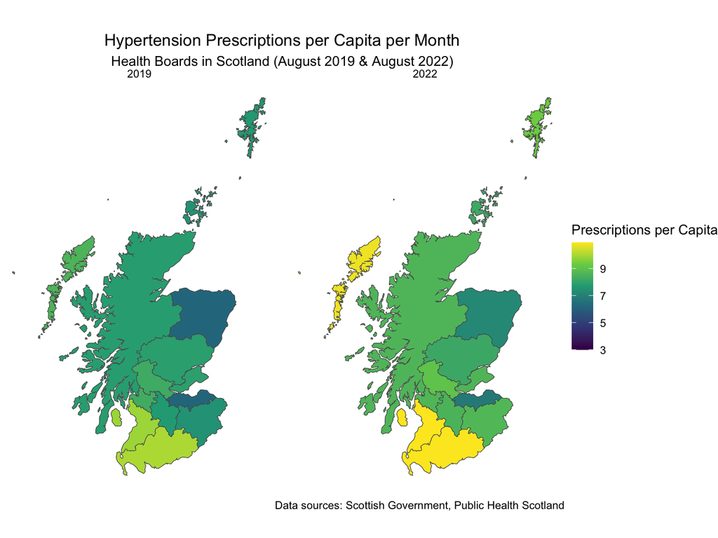

```r
hypertension_spatial <- ggplot(data = combined_spatial_data) +
  geom_sf(aes(fill = prescriptions_per_capita)) +
  scale_fill_viridis_c(name = "Prescriptions per Capita") +
  facet_wrap(~ year) +
  theme_void() +
  labs(title = "Hypertension Prescriptions per Capita per Month", subtitle = "Health Boards in Scotland (August 2019 & August 2022)", caption = "Data sources: Scottish Government, Public Health Scotland") +
  theme(legend.position = "right", plot.title = element_text(hjust = 0.5), plot.subtitle = element_text(hjust = 0.5))
#scale_fill_viridis_c() gives the plot a continuous scale, which is a better representation of our data as hypertension prescriptions per capita per month is a continuous variable.
hypertension_spatial
```

## 3 Conclusion

In conclusion, our data shows that hypertension prescriptions increased across Scotland over the COVID-19 Pandemic (from August 2019 to August 2022). However, it would be intriguing to explore if this was a significantly greater increase compared to the two years that followed (2022–2024) to see if hypertension prescriptions are still increasing rapidly post-pandemic.

## 4 Use of Generative AI

Generative AI was used only if internet research could not help to identify a new technique not already used in class. For example, to show how to use str_extract() to filter prescription data. It was also used for troubleshooting if code errors could not be identified using internet research. No code was directly copied from generative AI.

## References

Allen, PHS Christopher. 2024. “Why Did My GP Switch Me to a Different Beta-Blocker?” British Heart Foundation. https://www.opendata.nhs.scot/dataset/prescriptions-in-the-community.

Inform, NHS. 2024. “High Blood Pressure (Hypertension).” Scottish Government. https://www.nhsinform.scot/illnesses-and-conditions/cardiovascular-disease/risk-factors-for-cardiovascular-disease/high-blood-pressure-hypertension/.

Wroth-Smith, Jon. 2024. “Scotland’s Census 2022 - Health, Disability and Unpaid Care.” Scottish Government. https://www.scotlandscensus.gov.uk/2022-results/scotland-s-census-2022-health-disability-and-unpaid-care/.